# Tips_基本的な集計

Health Data Analysis

## Basics of how to create summary tables

Commands and processes for basic data aggregations using standard packages such as dpylyr, tidyr, purrr, stringr, ggplot2.

ここではMASSパッケージのAidsを例にする。

```r
df <- MASS::Aids2
df
```

```
   state sex  diag death status T.categ age
1    NSW   M 10905 11081      D      hs  35
2    NSW   M 11029 11096      D      hs  53
3    NSW   M  9551  9983      D      hs  42
4    NSW   M  9577  9654      D    haem  44
5    NSW   M 10015 10290      D      hs  39
6    NSW   M  9971 10344      D      hs  36
7    NSW   M 10746 11135      D   other  36
8    NSW   M 10042 11069      D      hs  31
9    NSW   M 10464 10956      D      hs  26
10   NSW   M 10439 10873      D    hsid  27
 [ reached 'max' / getOption("max.print") -- omitted 2833 rows ]
```

まずはtidyverseをload

```r
library(tidyverse)
```

データの次元の確認

```r
dim(df)
```

```
[1] 2843    7
```

見栄えよくしたい場合はdata.frameにしてしまう。

```r
dim_df <- data.frame(rows = nrow(df), columns = ncol(df))
dim_df
```

```
  rows columns
1 2843       7
```

名前の変更。setNamesはlist型の要素名をセットする。 変数（例えばaとする）のあとにパイプ演算子（ %>% ）と関数（例えばfとする）を入れると、 aに対してfを適用した結果を出すことになる。fの引数の中ではドット（“.”）と省略系してaを表すことができる。 第一引数の場合はそれも省略することが可能である。 第二引数以降の場合は省略せずに“.”をきちんと入れる必要がある。

```r
dim_df %>% setNames(., nm = c("N rows", "N cols"))
```

```
  N rows N cols
1   2843      7
```

カラムの内容の確認。各カラムのタイプはどうなっているか調べておく。 タイプには数値型(integer, double)、文字列型(character)、カテゴリ型(factor)などがある。 Rだと特にfactorの扱いには少し気をつける必要がある。 csvから読み込んだデータの場合は、読み込む際に特に指定しなければ読み込み関数が推定する。 読み込みの癖もあるので、よく使われる関数1, 2に絞って覚えておくのが良い。

```r
sapply(df, class)  # 'typeof' function are sequentially appled to df
```

```
    state       sex      diag     death    status   T.categ       age
 "factor"  "factor" "integer" "integer"  "factor"  "factor" "integer"
```

丁度factor型が出てきた。classは一皮かぶっているので、一段深く覗いてみる。

```r
sapply(df, typeof)
```

```
    state       sex      diag     death    status   T.categ       age
"integer" "integer" "integer" "integer" "integer" "integer" "integer"
```

一緒にすると

```r
bind_rows(sapply(df, class), sapply(df, typeof))
```

```
# A tibble: 2 x 7
  state   sex     diag    death   status  T.categ age
  <chr>   <chr>   <chr>   <chr>   <chr>   <chr>   <chr>
1 factor  factor  integer integer factor  factor  integer
2 integer integer integer integer integer integer integer
```

まどろっこしいことはやめてひと目で確認してみよう。

```r
str(df)
```

```
'data.frame':   2843 obs. of  7 variables:
 $ state  : Factor w/ 4 levels "NSW","Other",..: 1 1 1 1 1 1 1 1 1 1 ...
 $ sex    : Factor w/ 2 levels "F","M": 2 2 2 2 2 2 2 2 2 2 ...
 $ diag   : int  10905 11029 9551 9577 10015 9971 10746 10042 10464 10439 ...
 $ death  : int  11081 11096 9983 9654 10290 10344 11135 11069 10956 10873 ...
 $ status : Factor w/ 2 levels "A","D": 2 2 2 2 2 2 2 2 2 2 ...
 $ T.categ: Factor w/ 8 levels "hs","hsid","id",..: 1 1 1 5 1 1 8 1 1 2 ...
 $ age    : int  35 53 42 44 39 36 36 31 26 27 ...
```

```r
summary(df)
```

```
   state      sex           diag           death       status
 NSW  :1780   F:  89   Min.   : 8302   Min.   : 8469   A:1082
 Other: 249   M:2754   1st Qu.:10163   1st Qu.:10672   D:1761
 QLD  : 226            Median :10665   Median :11235
 VIC  : 588            Mean   :10584   Mean   :10990
                       3rd Qu.:11103   3rd Qu.:11504
                       Max.   :11503   Max.   :11504

    T.categ          age
 hs     :2465   Min.   : 0.00
 blood  :  94   1st Qu.:30.00
 hsid   :  72   Median :37.00
 other  :  70   Mean   :37.41
 id     :  48   3rd Qu.:43.00
 haem   :  46   Max.   :82.00
 (Other):  48
```

パッケージに付属の関数も利用しやすいものがいくつかある。

- mosaicを使用 inspect関数は型ごとに結果を出力してくれる。※ パッケージをlibrary(mosaic)でロードしておけば関数名のみ(inspect)で呼び出せるが、 異なるパッケージ内に同じ名前の関数があると、どちらかが優先されるため、あまり多くのパッケージのロードは避けたほうが良い。 mosaic::などとパッケージ名のあとに関数を指定することで、どのパッケージの関数を使うかを明示している。 この方法であれば、パッケージをインストールさえしてあれば、ロードなしで指定できる。

```r
inspected <- mosaic::inspect(df)
inspected[1]
```

```
$categorical
# A tibble: 4 x 6
  name    class  levels     n missing distribution
  <chr>   <chr>   <int> <int>   <int> <chr>
1 state   factor      4  2843       0 "NSW (62.6%), VIC (20.7%) ...       …
2 sex     factor      2  2843       0 "M (96.9%), F (3.1%)                …
3 status  factor      2  2843       0 "D (61.9%), A (38.1%)               …
4 T.categ factor      8  2843       0 "hs (86.7%), blood (3.3%) ...       …
```

- levelsカラムで層の数を把握できる
- missingカラムは欠損値の個数だが、このデータでは存在しない
- distributionカラムをみると、どの程度偏った集団になっているか把握できる。例えばこのデータでは男性が大半である。

男女といえば、年齢も気になるところ。最初から5歳毎、10歳毎などに区分されていることもあれば、連続値のこともある。 このデータにおいては連続値（整数）で格納されている。

```r
inspected[2]
```

```
$quantitative
# A tibble: 3 x 11
  name  class     min     Q1 median    Q3   max    mean    sd     n missing
  <chr> <chr>   <dbl>  <dbl>  <dbl> <dbl> <dbl>   <dbl> <dbl> <int>   <int>
1 diag  integer  8302 10163   10665 11103 11503 10584.  627.   2843       0
2 death integer  8469 10672.  11235 11504 11504 10990.  625.   2843       0
3 age   integer     0    30      37    43    82    37.4  10.1  2843       0
```

- psychを使用 若干仕様が異なってくる。好きなものを使うのが良い。

```r
psych::describe(df)
```

```
        vars    n     mean     sd median  trimmed    mad  min   max range
state*     1 2843     1.87   1.23      1     1.71   0.00    1     4     3
sex*       2 2843     1.97   0.17      2     2.00   0.00    1     2     1
diag       3 2843 10584.33 627.16  10665 10633.19 690.89 8302 11503  3201
death      4 2843 10990.26 625.37  11235 11097.95 398.82 8469 11504  3035
status*    5 2843     1.62   0.49      2     1.65   0.00    1     2     1
         skew kurtosis    se
state*   0.92    -0.93  0.02
sex*    -5.38    26.96  0.00
diag    -0.60    -0.34 11.76
death   -1.20     0.56 11.73
status* -0.49    -1.76  0.01
 [ reached 'max' / getOption("max.print") -- omitted 2 rows ]
```

さてageがintegerだったので、わかりやすい集計表にするには、これを区切っていく必要がある。 区分がビジネス上の要件で決まる場合もあるので、区切り方は一通りではない。まずヒストグラムを見てみよう。

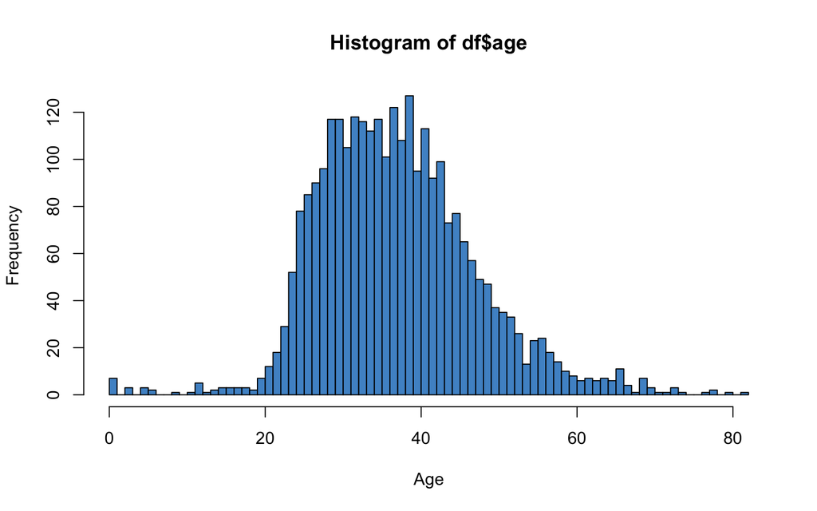

```r
hist(df$age, col = "steelblue3", breaks = 100, xlab = "Age")
```

見た目を整えたい場合や複雑な場合はggplotを使うのがおすすめ

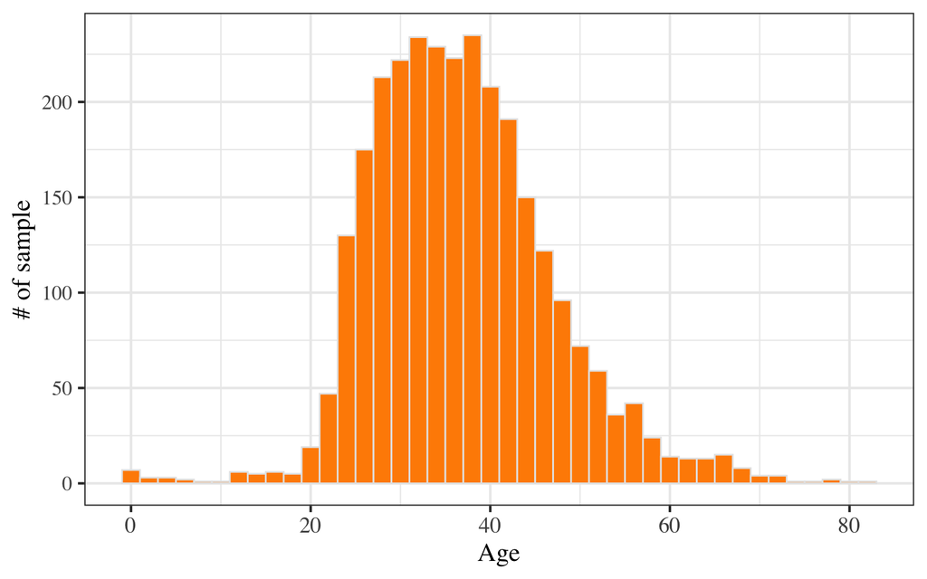

```r
df %>% ggplot(data = .) + geom_histogram(aes(x = age), fill = "darkorange",
    color = "gray90", binwidth = 2) + theme_bw(base_size = 16, base_family = "Times") +
    xlab("Age") + ylab("# of sample") + theme(axis.text.x = element_text(size = 14))
```

ここでは10年刻みにしたカラムを作成してみる。maxは82歳, minは0となっているから、

```r
new_age_col <- "age_c"
df[[new_age_col]] <- cut(df$age, breaks = seq(0, 90, 10), include.lowest = T,
    right = F)
df[[new_age_col]]
```

```
 [1] [30,40) [50,60) [40,50) [40,50) [30,40) [30,40) [30,40) [30,40)
 [9] [20,30) [20,30) [40,50) [30,40) [20,30) [30,40) [30,40) [30,40)
[17] [30,40) [20,30) [50,60) [40,50) [20,30) [30,40) [20,30) [30,40)
[25] [40,50) [10,20) [30,40) [30,40) [30,40) [0,10)  [30,40) [30,40)
[33] [30,40) [30,40) [30,40) [40,50) [50,60) [20,30) [20,30) [30,40)
[41] [40,50) [30,40) [50,60) [30,40) [20,30) [20,30) [40,50) [40,50)
[49] [20,30) [30,40) [30,40) [20,30) [30,40) [30,40) [30,40) [30,40)
[57] [40,50) [50,60) [30,40) [40,50) [30,40) [30,40) [30,40) [30,40)
[65] [30,40) [40,50) [40,50) [40,50) [30,40) [40,50) [20,30) [40,50)
[73] [30,40) [40,50) [50,60)
 [ reached getOption("max.print") -- omitted 2768 entries ]
9 Levels: [0,10) [10,20) [20,30) [30,40) [40,50) [50,60) ... [80,90]
```

だいぶ偏りはあるが、以下のようになった。

```r
df[[new_age_col]] %>% table(exclude = NULL)
```

```
.
 [0,10) [10,20) [20,30) [30,40) [40,50) [50,60) [60,70) [70,80) [80,90]
     16      23     584    1143     767     233      63      12       2
```

区切り方を変更してみよう。

```r
df[[new_age_col]] <- cut(df$age, breaks = c(0, 30, 50, 90), right = F, include.lowest = T)
df[[new_age_col]] %>% table(exclude = NULL)
```

```
.
 [0,30) [30,50) [50,90]
    623    1910     310
```

```r
df %>% select(age_c, sex) %>% table
```

```
         sex
age_c        F    M
  [0,30)    32  591
  [30,50)   32 1878
  [50,90]   25  285
```

外に出力したい場合 + クリップボードにコピー これは、そのままペーストコマンドでexcelなどに貼り付けることが可能

```r
df %>% select(age_c, sex) %>% table %>% xtable::xtable() %>% print(type = "html",
    file = "clipboard-128")
```

- 診断と脂肪の時間差を表すカラムを追加する。y = ..density..の指定とposition = “identity” (その他“stack”, “jitter”など)に注意

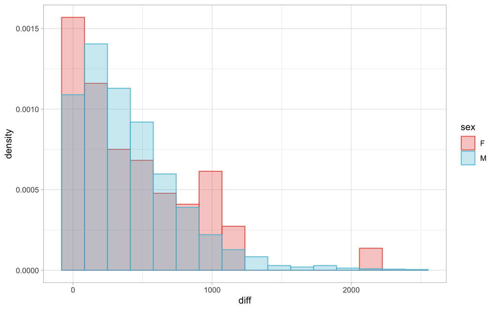

```r
library(RColorBrewer)
library(ggsci)
library(scico)

df %>% mutate(diff = death - diag) %>% arrange(diff) %>% ggplot() + geom_histogram(aes(x = diff,
    fill = sex, color = sex, y = ..density..), position = "identity", bins = 16) +
    scale_fill_npg(alpha = 0.3) + scale_color_npg(alpha = 0.8) + theme_light()
```

- さらに年齢でも分けてみる。 年齢が上がるほど診断から死に至るまでの時間は短いと言える。ただし、寿命も関係すると考えられるので、特に老人においてこの病気が死亡時期を早める影響が強いかどうかはまだ不明である。

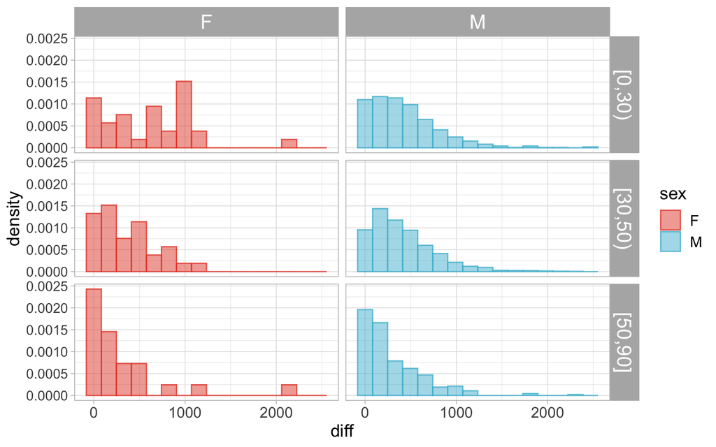

```r
df %>% mutate(diff = death - diag) %>% arrange(diff) %>% ggplot() + geom_histogram(aes(x = diff,
    y = ..density.., fill = sex, color = sex), bins = 16) + facet_grid(~age_c ~
    sex) + theme_light() + scale_fill_npg(alpha = 0.5) + scale_color_npg(alpha = 0.8) +
    theme(strip.text.x = element_text(size = 16), strip.text.y = element_text(size = 16),
        axis.text.x = element_text(size = 12), axis.text.y = element_text(size = 11),
        axis.title.x = element_text(size = 14), axis.title.y = element_text(size = 14),
        legend.title = element_text(size = 14), legend.text = element_text(size = 12))
```

- 時間も区切り、早くに死亡した人の割合を見てみる。

```r
df <- df %>% mutate(diff = death - diag, diff_c = cut(diff, breaks = c(0, 200,
    500, Inf), right = F, include.lowest = T))
df %>% select(age_c, sex, diff_c) %>% mutate(early_death = ifelse(diff_c ==
    "[0,200)", 1, 0)) %>% group_by(sex, age_c) %>% summarize(count = n(), early_death = sum(early_death,
    na.rm = T)) %>% mutate(ratio = early_death/count)
```

```
# A tibble: 6 x 5
# Groups:   sex [2]
  sex   age_c   count early_death ratio
  <fct> <fct>   <int>       <dbl> <dbl>
1 F     [0,30)     32           9 0.281
2 F     [30,50)    32          11 0.344
3 F     [50,90]    25          14 0.56
4 M     [0,30)    591         188 0.318
5 M     [30,50)  1878         613 0.326
6 M     [50,90]   285         156 0.547
```

### 喫煙のリスクのはなし

さてここからはある書籍に紹介されていた喫煙リスクの話。

```r
smoke_t1 <- expand.grid(c("reach20", "no"), c("lcd", "well")) %>% mutate(count = c(56,
    32, 25405, 21863)) %>% spread(key = Var2, value = count)
names(smoke_t1)[1] <- "smoke"
smoke_t1
```

```
    smoke lcd  well
1 reach20  56 25405
2      no  32 21863
```

```r
smoke_t2 <- data.frame(smoke = c("no", "under20", "reach20"), death = c(32,
    86, 56), count = c(21895, 44184, 25461))
smoke_t2
```

```
    smoke death count
1      no    32 21895
2 under20    86 44184
3 reach20    56 25461
```

```
     age_c     work   smoke death count
1  [40_59]     aggr      no     3  5999
2  [40_59]     aggr under20    20 12753
3  [40_59]     aggr reach20    16  7150
4  [40_59] non_aggr      no     8  8021
5  [40_59] non_aggr under20    20 17923
6  [40_59] non_aggr reach20    20 13434
7    [60-)     aggr      no    14  4407
8    [60-)     aggr under20    32  7291
9    [60-)     aggr reach20     8  2241
10   [60-) non_aggr      no     7  3468
11   [60-) non_aggr under20    14  6217
12   [60-) non_aggr reach20    12  2636
```

まずはtable1分割表における$\chi^2$検定量から。 $\chi^2$検定で検定している仮説としては、帰無仮説:$p_{ij} = p_{i}p_{j}$で対立仮説$p_{ij}\ne p_{i}p_{j}$ また、
$$\chi^2 = \frac{( y_{ij} - y_{i.}y_{.j}/y_{..} )^2}{y_{i.} y_{.j}/y_{..}} \space\space のすべてのセルに関する和$$

である。

```
    Pearson's Chi-squared test

data:  smoke_t1[, 2:3] %>% as.matrix
X-squared = 3.4559, df = 1, p-value = 0.06303
```

```
          lcd      well         lcd1     well1
1 0.000999098 0.5366519 0.0011825323 0.5364685
2 0.000859167 0.4614898 0.0006757327 0.4616733
```

$\chi^2$統計量を自分で算出してみよう。

```r
smoke_t1_matrix <- smoke_t1 %>% select(-1) %>% as.matrix
rowSums(smoke_t1_matrix) %x% (colSums(smoke_t1_matrix) %>% t)/sum(smoke_t1_matrix)
```

```
         [,1]     [,2]
[1,] 47.31329 25413.69
[2,] 40.68671 21854.31
```

```r
bunshi_ <- (smoke_t1_matrix - (rowSums(smoke_t1_matrix) %x% (colSums(smoke_t1_matrix) %>%
    t))/sum(smoke_t1_matrix))
bunbo_ <- sqrt(prod(c(rowSums(smoke_t1_matrix), colSums(smoke_t1_matrix)))/sum(smoke_t1_matrix)^3)

chisq_bunshi <- bunshi_^2
chisq_bunbo <- (rowSums(smoke_t1_matrix) %x% (colSums(smoke_t1_matrix) %>% t))/sum(smoke_t1_matrix)

chi2_stat <- (chisq_bunshi/chisq_bunbo) %>% sum
pchi2 <- 1 - pchisq(3.455936, df = 1)
c(chi2_stat, pchi2)
```

```
[1] 3.45593620 0.06302504
```

これは、次のコマンドの結果に等しい

```r
chisq.test(as.matrix(smoke_t1_matrix), correct = F)
```

```
    Pearson's Chi-squared test

data:  as.matrix(smoke_t1_matrix)
X-squared = 3.4559, df = 1, p-value = 0.06303
```

ちなみに$u_{11}$統計量は

```
     lcd
1.859015
```

喫煙の例では、「喫煙」の「肺がんでの死亡」との関連において、年齢が交絡因子となっている。

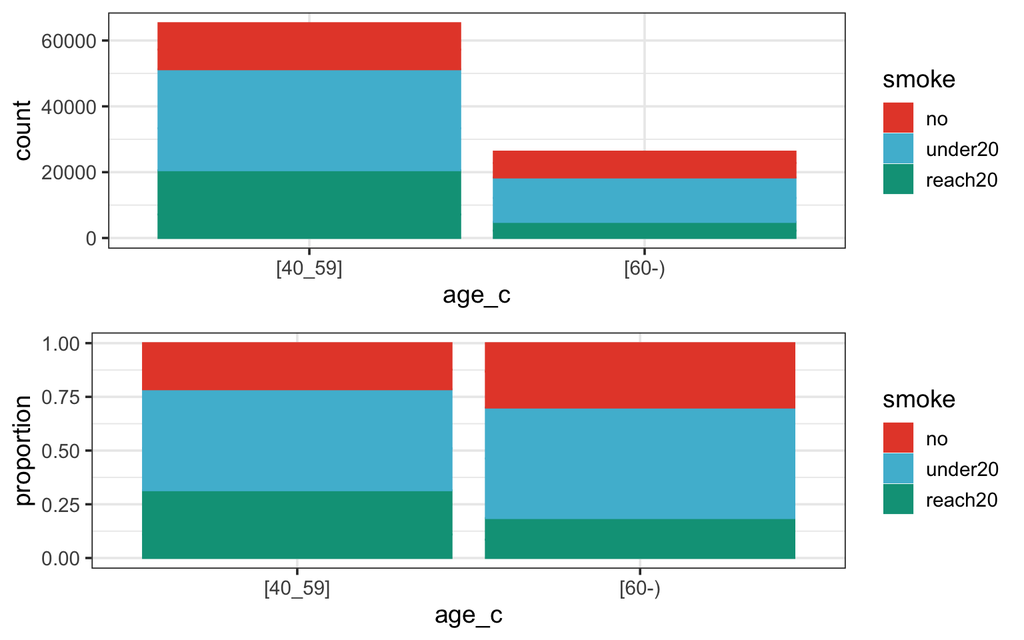

```r
p1 <- smoke_t3 %>% ggplot() + geom_bar(aes(x = age_c, y = count, color = smoke,
    fill = smoke), stat = "identity") + theme_bw(base_size = 14) + scale_color_npg() +
    scale_fill_npg()
p2 <- smoke_t3 %>% group_by(age_c) %>% mutate(sum_count = sum(count)) %>% ungroup %>%
    ggplot() + geom_bar(aes(x = age_c, y = count/sum_count, color = smoke, fill = smoke),
    stat = "identity") + theme_bw(base_size = 14) + scale_color_npg() + scale_fill_npg() +
    ylab("proportion")

gridExtra::grid.arrange(p1, p2)
```

もっとわかりやすいのは以下の見方かもしれない。 + 年齢区分で分離した場合、総じて肺がんでの死亡率は高齢の方が高い。 + 60歳以上の集団では、1日20本以上の喫煙者の割合（緑）が40歳以上60歳未満のそれに比べて小さい。

もし年齢区分によらずこれらの集団の人数割合が同程度であれば、2つの集団を一緒にしてしまった場合でも 同じリスク差が出るはずであるが、この例ではバランスが違うので、「40-59の集団に高齢者集団を混ぜる」と考えたとき、 「もともとリスクの高い非喫煙者」が増える(14020人に対し7875人)割には「さらにリスクの高いヘビースモーカー」が増えない(20584人に対して4877人)。

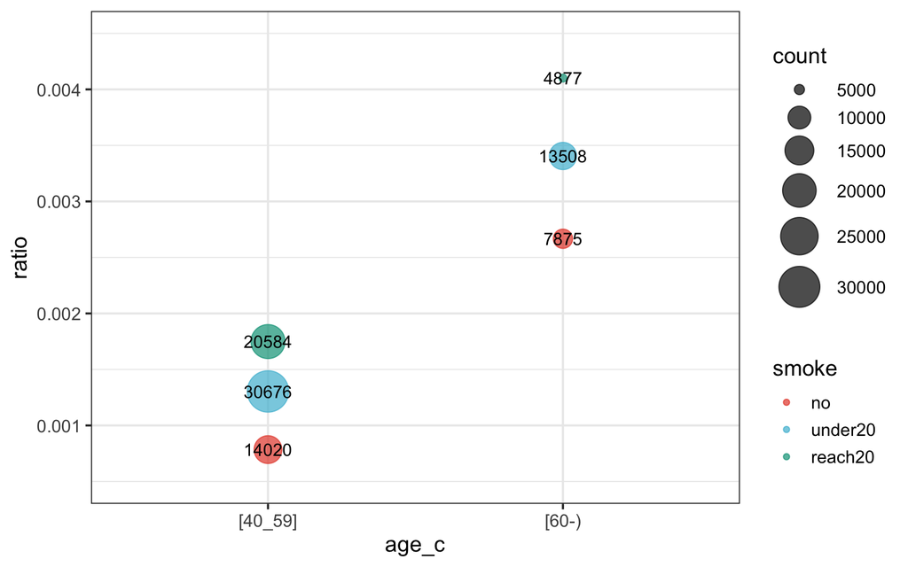

```
# A tibble: 6 x 4
  age_c   smoke   data             chisq_raw
  <fct>   <fct>   <list>           <list>
1 [40_59] no      <tibble [2 × 3]> <fn>
2 [40_59] under20 <tibble [2 × 3]> <fn>
3 [40_59] reach20 <tibble [2 × 3]> <fn>
4 [60-)   no      <tibble [2 × 3]> <fn>
5 [60-)   under20 <tibble [2 × 3]> <fn>
6 [60-)   reach20 <tibble [2 × 3]> <fn>
```

```
[[1]]

    Pearson's Chi-squared test

data:  .x %>% select("death", "others")
X-squared = 6.6172, df = 2, p-value = 0.03657


[[2]]

    Pearson's Chi-squared test

data:  .x %>% select("death", "others")
X-squared = 1.2831, df = 2, p-value = 0.5265


[[3]]

    Pearson's Chi-squared test

data:  .x %>% select("death", "others")
X-squared = 1.1099, df = 2, p-value = 0.5741


[[4]]

    Pearson's Chi-squared test

data:  .x %>% select("death", "others")
X-squared = 4.4543, df = 2, p-value = 0.1078
```

```
  death others
A     3   5996
B    20  12733
C    16   7134
```

```
  death others
A     8   8013
B    20  17903
C    20  13414
```

```
  death others
A    14   4393
B    32   7259
C     8   2233
```

```
  death others
A     7   3461
B    14   6203
C    12   2624
```

```
, , 1

            lung_cancer_death normal
smoke = 0                   3   5996
smoke < 20                 20  12733
smoke >= 20                16   7134

, , 2

            lung_cancer_death normal
smoke = 0                   8   8013
smoke < 20                 20  17903
smoke >= 20                20  13414

, , 3

            lung_cancer_death normal
smoke = 0                  14   4393
smoke < 20                 32   7259
smoke >= 20                 8   2233

, , 4

            lung_cancer_death normal
smoke = 0                   7   3461
smoke < 20                 14   6203
smoke >= 20                12   2624
```

```r
p3 <- smoke_t3 %>% group_by(age_c, smoke) %>% select(-work) %>% summarize_all(sum) %>%
    mutate(ratio = death/count) %>% ggplot() + geom_point(aes(x = age_c, color = smoke,
    y = ratio, size = count), alpha = 0.7) + geom_text(aes(x = age_c, y = ratio,
    label = count)) + theme_bw(base_size = 14) + scale_color_npg() + ylim(c(5e-04,
    0.0045)) + scale_size(range = c(2, 12))
p3
```

4つの層を合成した$\chi^2$統計量で検定を行う

```
    Cochran-Mantel-Haenszel test

data:  tab
Cochran-Mantel-Haenszel M^2 = 8.0949, df = 2, p-value = 0.01747
```

Tomoya Saito

2020-01-03